# Dow Jones News Fund Data Interns 2026

(ver May 3, 2026)

[figure not shown]

[figure not shown]

[figure not shown]

Emily Wilson studies at Craig Newmark Graduate School of Journalism at CUNY and will intern at the Advertising Specialty Institute

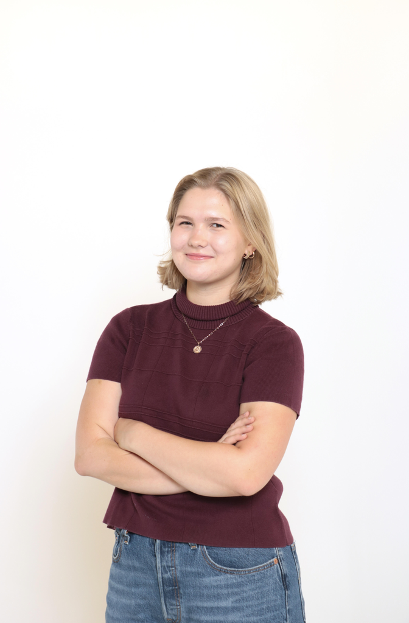

Casey Mann studies at University of Arkansas - Fayetteville and will intern at the Arkansas Democrat-Gazette

Laine Cibulskis studies at University of Missouri - Columbia and will intern at Detroit News

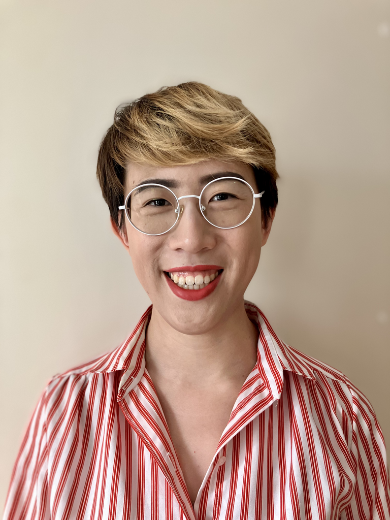

Julie Lee studies at Columbia University and will intern at the Howard Center for Investigative Journalism

Diego Torrealba studies at University of Texas at Austin and will intern at the Howard Center for Investigative Journalism

Tiasia Saunders studies at University of Maryland and will intern at the Investigative Project on Race and Equity

Ela Jalil studies at University of Maryland and will intern at the Investigative Reporting Workshop

Will Hammann studies at University of Maryland and will intern at the Maryland Matters

Izzy Farina studies at University of Georgia and will intern at the NJ Advance Media

[figure not shown]

Yaelle Tang studies at University of California, Berkeley and will intern at the Philadelphia Inquirer

Katelynn Winebrenner studies at University of Maryland and will intern at The Frederick News-Post

Teresa Do studies at University of Texas at Austin and will intern at The Trace